# Activity monitoring data

Hans

11/28/2020

### What is mean total number of steps taken per day?

- Calculate the total number of steps taken per day

```r
comps <- complete.cases(activity$steps)
completes <- activity[comps,]
by_day <- aggregate(x = completes$steps,
    by = list(completes$date),
    FUN = sum)
colnames(by_day) <- c("Day", "Steps")
print(by_day)
```

```
##           Day Steps
## 1  2012-10-02   126
## 2  2012-10-03 11352
## 3  2012-10-04 12116
## 4  2012-10-05 13294
## 5  2012-10-06 15420
## 6  2012-10-07 11015
## 7  2012-10-09 12811
## 8  2012-10-10  9900
## 9  2012-10-11 10304
## 10 2012-10-12 17382
## 11 2012-10-13 12426
## 12 2012-10-14 15098
## 13 2012-10-15 10139
## 14 2012-10-16 15084
```

[output cut: 39 more lines]

- Make a histogram of the total number of steps taken each day

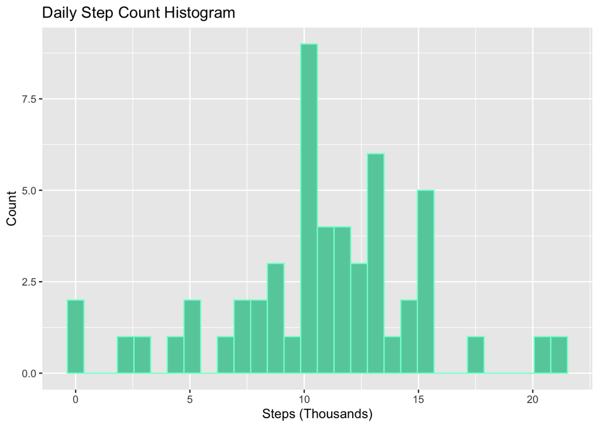

```r
steps_histogram <- ggplot(by_day, aes(x=Steps/1000)) + geom_histogram(color="aquamarine", fill="aquamarine3") +
      labs(title="Daily Step Count Histogram", y="Count", x="Steps (Thousands)")
steps_histogram
```

- Calculate and report the mean and median of the total number of steps taken per day

```r
median(by_day$Steps)
```

```
## [1] 10765
```

```r
mean(by_day$Steps)
```

```
## [1] 10766.19
```

The average number of daily steps is 10,766.19. The median number of daily steps is 10,765.

### What is the average daily activity pattern?

- Make a time series plot of the 5-minute interval and the average number of steps taken, averaged across all days

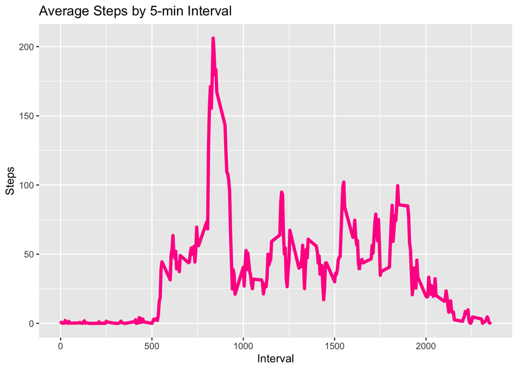

```r
days <- nrow(by_day)

by_interval <- aggregate(x = completes$steps,
                    by = list(completes$interval),
                    FUN = sum)

colnames(by_interval) <- c("Interval", "Steps")

by_interval$Steps <- by_interval$Steps/days

interval_series <- ggplot(by_interval, aes(x=Interval, y=Steps)) + geom_line(color="deeppink", size=1.5)
interval_series + labs(title="Average Steps by 5-min Interval", y="Steps") + theme(legend.position="none")
```

- Which 5-minute interval, on average across all the days in the dataset, contains the maximum number of steps?

```r
max_row <- which.max(by_interval$Steps)
by_interval$Interval[max_row]
```

```
## [1] 835
```

```r
by_interval$Steps[max_row]/days
```

```
## [1] 3.889996
```

### Imputing missing values

- Calculate and report the total number of missing values in the dataset

```r
missing_values <- sum(is.na(activity[,1]))
missing_values
```

```
## [1] 2304
```

```r
missing_values/((60*24)/5)
```

```
## [1] 8
```

There are 2,304 rows with NA in the dataset. These are the result of 8 full days of missing data.

- Devise a strategy for filling in all of the missing values in the dataset My script imputes the NA values using the mean for each 5 minute interval across all days.

*Create a new dataset that is equal to the original dataset but with the missing data filled in

```r
NAs <- subset(activity, is.na(activity[,1]))

for(i in 1:nrow(NAs)) {
  NAs$steps <-by_interval[match(NAs$interval, by_interval$Interval),2]
}

colnames(NAs) <- c("Steps", "Date", "Interval")
colnames(completes) <- c("Steps", "Date", "Interval")

combined <- rbind(NAs, completes)

by_day_combined <- aggregate(x = combined$Steps,
                    by = list(combined$Date),
                    FUN = sum)

colnames(by_day_combined) <- c("Date", "Steps")
```

- Make a histogram of the total number of steps taken each day

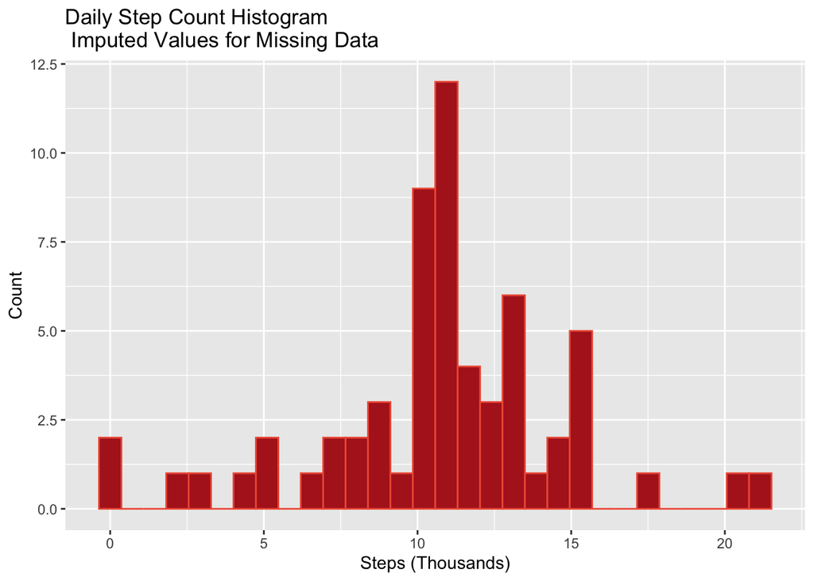

```r
combined_histogram <- ggplot(by_day_combined, aes(x=Steps/1000)) + geom_histogram(color="tomato2", fill="firebrick") +
  labs(title="Daily Step Count Histogram \n Imputed Values for Missing Data", y="Count", x="Steps (Thousands)")
combined_histogram
```

- Calculate and report the mean and median daily steps

```r
mean(by_day_combined$Steps)
```

```
## [1] 10766.19
```

```r
median(by_day_combined$Steps)
```

```
## [1] 10766.19
```

The mean was the same as before: 10,766.19 steps. The median is 1.19 steps higher, changing from 10,765 steps to 10766.19 steps.

The impact of imputing missing data on these measures of central tendency was relatively small.

### Are there differences in activity patterns between weekdays and weekends?

Subject is generally more active on weekdays. Activity levels are skewed earlier on weekdays.

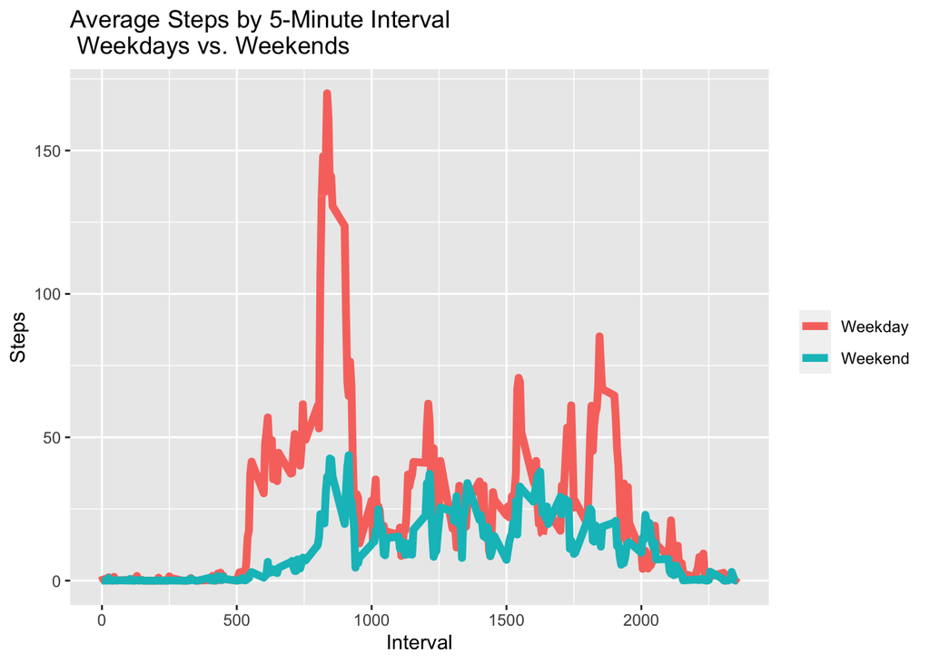

```r
combo <- rbind(completes, NAs)

combo$DOW <- weekdays(combo$Date)

weekends <- subset(combo, DOW=="Saturday" | DOW=="Sunday")
weekends$is_weekend <- "Weekend"

weekdays <- subset(combo, DOW=="Monday" | DOW=="Tuesday" | DOW=="Wednesday" | DOW=="Thursday" | DOW=="Friday")
weekdays$is_weekend <- "Weekday"

WDs_by_int <- aggregate(x = weekends$Steps,
                         by = list(weekends$Interval),
                         FUN = sum)

WDs_by_int$is_weekend <- "Weekend"

WEs_by_int <- aggregate(x = weekdays$Steps,
                        by = list(weekdays$Interval),
                        FUN = sum)

WEs_by_int$is_weekend <- "Weekday"

days_with_imp <- length(unique(combo$Date))

combo_days <- rbind(WDs_by_int, WEs_by_int)
colnames(combo_days) <- c("Interval", "Steps", "DOW")
combo_days$Steps <- combo_days$Steps/days_with_imp

final_plot <- ggplot(combo_days, aes(x=Interval, y=Steps, group=DOW, color=DOW))
final_plot + geom_line(size=2) + labs(y="Steps", title="Average Steps by 5-Minute Interval \n Weekdays vs. Weekends") + theme(legend.title =element_blank())
```